# Text Prediction Milestone Report

Eric Scuccimarra

27 January 2018

## Summary

The project is to create a text prediction algorithm using data supplied by Swiftkey. The data is text from online news sources, blogs and Twitter. I am using the English language data.

## Loading the Data

The data is read in from the three text files.

```r
# Read the  data in
blog <- readLines("final/en_US/en_US.blogs.txt", encoding="UTF-8")
twitter <- readLines("final/en_US/en_US.twitter.txt", encoding="UTF-8")
news <- readLines("final/en_US/en_US.news.txt", encoding="UTF-8")
```

```r
set.seed(123455)
rfilter <- rbinom(length(twitter), size=1, prob=0.25)
filter <- rfilter == 1
twitter <- twitter[filter]

rfilter <- rbinom(length(blog), size=1, prob=0.25)
filter <- rfilter == 1
blog <- blog[filter]
```

Finally the three data sets are combined into one corpus and non-ASCII characters are removed.

```r
text = c(news, twitter, blog)

# Remove non-ASCII characters
text = iconv(text, "latin1", "ASCII", sub="")
rm(blog,profanity,twitter,news,filter,rfilter)
```

## Data Summary

To give an overview of the data it is converted into a TextDocumentMatrix using the tm library.

```r
corpus <- VCorpus(VectorSource(text))
tdm <- as.matrix(TermDocumentMatrix(corpus, control = list(wordLengths = c(3, Inf))))
frequencycount <- rowSums(tdm)
frequencycount <- sort(frequencycount, decreasing=TRUE)
```

We can use this to see the most common words.

```r
head(frequencycount, 12)
```

[output not shown]

Or we can look at a word cloud:

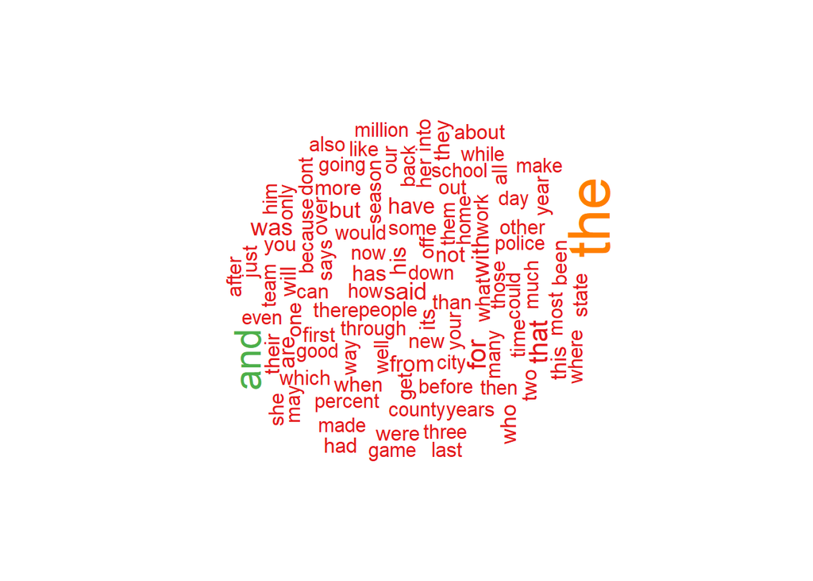

```r
wordcloud(corpus, scale=c(3,1), min.freq=10, max.words=100, random.order=TRUE,
          rot.per=0.5, colors=brewer.pal(5, "Set1"),  use.r.layout=FALSE)
```

## Tokenizing the Data

```r
twograms <- tokenize_ngrams(text, lowercase=TRUE, n=2L, n_min=2L, simplify=TRUE)
twograms <- unlist(twograms)
twogramfreq = as.data.frame(table(twograms))
twogramfreq <- twogramfreq[order(-twogramfreq$Freq),]

threegrams <- tokenize_ngrams(text, lowercase=TRUE, n=3L, n_min=3L, simplify=TRUE)
threegrams <- unlist(threegrams)
threegramfreq = as.data.frame(table(threegrams))
threegramfreq <- threegramfreq[order(-threegramfreq$Freq),]
```

This will allow us to view the most common two and three grams:

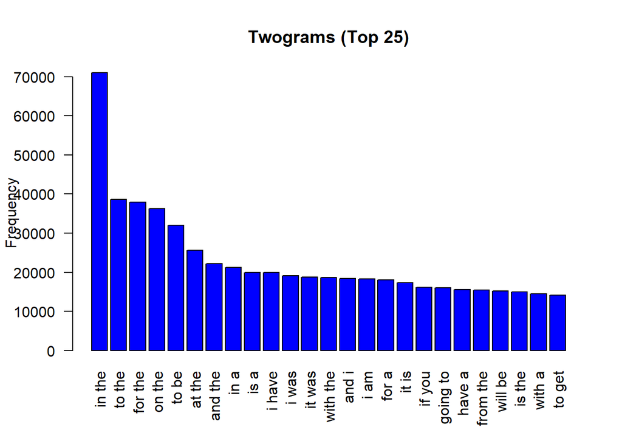

```r
barplot(twogramfreq[2:26,2],
        names.arg=twogramfreq[2:26,1],
        col = "blue",
        main="Twograms (Top 25)",
        las=2,
        ylab = "Frequency")
```

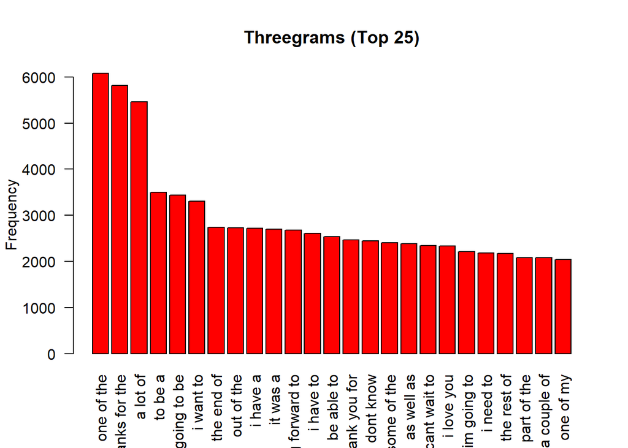

```r
barplot(threegramfreq[1:25,2],
        names.arg=threegramfreq[1:25,1],
        col = "red",
        main="Threegrams (Top 25)",
        las=2,
        ylab = "Frequency")
```

Note that the most common two gram was “a a” which has been removed due to not being a valid phrase.

## Plans for Algorithm

I have attempted to input the tokenized text into a decision tree algorithm, but was unable to do so due to the high amount of RAM required.

My plan is to create a feature matrix of ngrams with the y as the last word and the features as the preceding words. This should enable me to filter down the possible matches by looping through the input string and reducing the set of matches for each word. In the end the top three matches will be returned.

Some issues which will need to be addressed to accomplish this:

1. The corpus contains many words which are not valid English words or are names. Ideally the spelling errors or non-words would be filtered out. I am not sure how to handle names of people or places yet.
2. Much of the text is not grammatically correct. Ideally these would be filtered out, although time and processing power may make that difficult for this demo.
3. I am not yet sure how to handle input that does not match an existing ngram.